# AW_Maciej_Śmiałowski_Projekt_2

Maciej Śmiałowski

12 01 2021

## Cel

Celem projektu jest utworzenie modelu VAR. Aby to zrobić w poprawny sposób niezbędne jest wybranie odpowiedniej liczby opóźnień.Zatem ważnym aspektem tej pracy będzie również dostosowanie danych do estymacji modelu. Ponadto zostaną zbadane reakcje na impuls.

### Biblioteki:

```r
library(kableExtra)
library(zoo)
library(vars)
library(dplyr)
library(lubridate)
library(tseries)
library(ggplot2)
library(ggpubr)
library(tidyr)
```

## Dane

Dane w niniejszej pracy pochodzą ze strony https://stooq.pl odnoszą się do światowych indeksów giełdowych. Są to dane dzienne pochodzące z lat 2010-2020.

Dane odnoszą się do poniższych indeksów giełdowych

- **WIG** Polski indeks giełdowy
- **DAX** Niemiecki indeks giełdowy
- **FTSE** Brytyjski indeks giełdowy
- **SHC** Chiński indeks giełdowy
- **S&P 500** indeks giełdowy USA

Wczytywanie danych:

```r
rm(list=ls())
temp = list.files(pattern = "*.csv")
list2env(lapply(setNames(temp, make.names(gsub("*_d.csv$", "", temp))), read.csv), envir = .GlobalEnv)
```

```
## <environment: R_GlobalEnv>
```

Połączenie danych ze wszystkich indeksów w jedną ramkę. Wykorzystane zostaną jedynie dane zamknięcia.

```r
dane <- merge(x = wig[, c(1,5)], y = X.dax[, c(1,5)], by = "Data", all = TRUE)
dane <- merge(x = dane, y = X.ftm[, c(1,5)], by = "Data", all = TRUE)
dane <- merge(x = dane, y = X.shc[, c(1,5)], by = "Data", all = TRUE)
dane <- merge(x = dane, y = X.spx[, c(1,5)], by = "Data", all = TRUE)

#ustawienie odpowiedniego formatu daty
dane$Data <- ymd(dane$Data)
#ustawienie nazw kolumn
colnames(dane) <- c("data", "Polska", "Niemcy", "UK", "Chiny", "USA")
```

Ze względu że dane posiadają różną liczbę obserwacji zdecydowano się na uzupełnienie brakujących wartości poprzez proces interpolacji liniowej:

```r
dane <- data.frame(na.approx(read.zoo(dane)))
```

Podstawowe statystyki opisowe:

```r
summary(dane)
```

```
##      Polska          Niemcy            UK            Chiny           USA
##  Min.   :36549   Min.   : 5072   Min.   : 9426   Min.   :1950   Min.   :1099
##  1st Qu.:46718   1st Qu.: 8125   1st Qu.:14031   1st Qu.:2345   1st Qu.:1628
##  Median :51275   Median :10350   Median :16951   Median :2884   Median :2081
##  Mean   :51455   Mean   :10105   Mean   :16339   Mean   :2820   Mean   :2149
##  3rd Qu.:57290   3rd Qu.:12145   3rd Qu.:19151   3rd Qu.:3159   3rd Qu.:2694
##  Max.   :67529   Max.   :13789   Max.   :22108   Max.   :5166   Max.   :3662
```

Prezentacja zestawionych danych:

|  | Polska | Niemcy | UK | Chiny | USA |
| --- | --- | --- | --- | --- | --- |
| 2010-12-01 | 46145.34 | 6866.630 | 10809.33 | 2823.450 | 1206.070 |
| 2010-12-02 | 46481.15 | 6957.610 | 11076.80 | 2843.610 | 1221.530 |
| 2010-12-03 | 46868.43 | 6947.720 | 11082.17 | 2842.430 | 1224.710 |
| 2010-12-06 | 47348.16 | 6954.380 | 11151.35 | 2857.180 | 1223.120 |
| 2010-12-07 | 47516.57 | 7001.910 | 11299.44 | 2875.860 | 1223.750 |
| 2010-12-08 | 47554.07 | 6975.870 | 11218.69 | 2848.550 | 1228.280 |
| 2010-12-09 | 47465.15 | 6964.160 | 11263.38 | 2810.950 | 1233.000 |
| 2010-12-10 | 47510.17 | 7006.170 | 11280.96 | 2841.040 | 1240.400 |
| 2010-12-13 | 47649.66 | 7029.390 | 11359.73 | 2922.950 | 1240.460 |
| 2010-12-14 | 47637.57 | 7027.400 | 11409.81 | 2927.080 | 1241.590 |
| 2010-12-15 | 47892.91 | 7016.370 | 11372.81 | 2911.410 | 1235.230 |
| 2010-12-16 | 47516.86 | 7024.400 | 11329.04 | 2898.140 | 1242.870 |
| 2010-12-17 | 47651.54 | 6982.450 | 11426.78 | 2893.740 | 1243.910 |
| 2010-12-20 | 47363.90 | 7018.600 | 11433.11 | 2852.920 | 1247.080 |
| 2010-12-21 | 47732.90 | 7077.990 | 11506.65 | 2904.120 | 1254.600 |
| 2010-12-22 | 47693.24 | 7067.920 | 11550.16 | 2877.900 | 1258.840 |
| 2010-12-23 | 47718.80 | 7057.690 | 11569.22 | 2855.220 | 1256.770 |
| 2010-12-24 | 47688.13 | 7035.950 | 11492.88 | 2835.160 | 1256.963 |
| 2010-12-27 | 47596.12 | 6970.730 | 11574.49 | 2781.400 | 1257.540 |
| 2010-12-28 | 47422.73 | 6972.100 | 11601.69 | 2732.990 | 1258.510 |
| 2010-12-29 | 47911.46 | 6995.470 | 11628.89 | 2751.530 | 1259.780 |
| 2010-12-30 | 47700.76 | 6914.190 | 11569.43 | 2759.580 | 1257.880 |
| 2010-12-31 | 47489.91 | 6933.078 | 11558.80 | 2808.080 | 1257.640 |
| 2011-01-03 | 48004.74 | 6989.740 | 11681.62 | 2841.508 | 1271.890 |
| 2011-01-04 | 47616.84 | 6975.350 | 11722.56 | 2852.650 | 1270.200 |
| 2011-01-05 | 47075.74 | 6939.820 | 11741.57 | 2838.590 | 1276.560 |
| 2011-01-06 | 46963.07 | 6981.390 | 11716.87 | 2824.200 | 1273.850 |
| 2011-01-07 | 46850.41 | 6947.840 | 11674.35 | 2838.800 | 1271.500 |
| 2011-01-10 | 46416.30 | 6857.060 | 11575.26 | 2791.810 | 1269.750 |
| 2011-01-11 | 46678.96 | 6941.570 | 11735.26 | 2804.050 | 1274.480 |

[output cut: 2573 more lines]

Graficzne przedstawienie zestawionych danych:

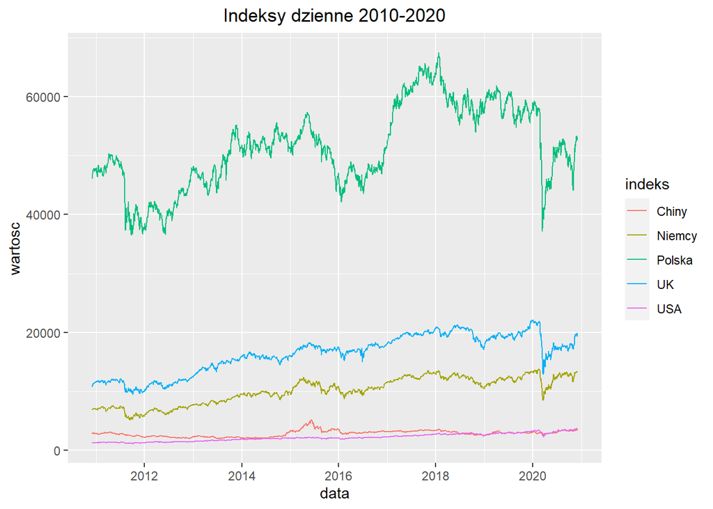

Funkcja licząca logarytmiczne stopy zwrotu z indeksów giełdowych.

```r
log_f <- function(indeks) {
  log_stopy <- 0

  for(i in 1:length(indeks)-1) {
    log_stopy[i] <- log(indeks[i+1] / indeks[i])
  }
  log_stopy
}
```

Zastosowanie funkcji liczącej logarytmiczne stopy zwrotu z indeksów:

```r
stopy_df <- data.frame(sapply(dane, function(x) log_f(x)))
stopy_df <- cbind(data = dane_data$data[-1], stopy_df)
```

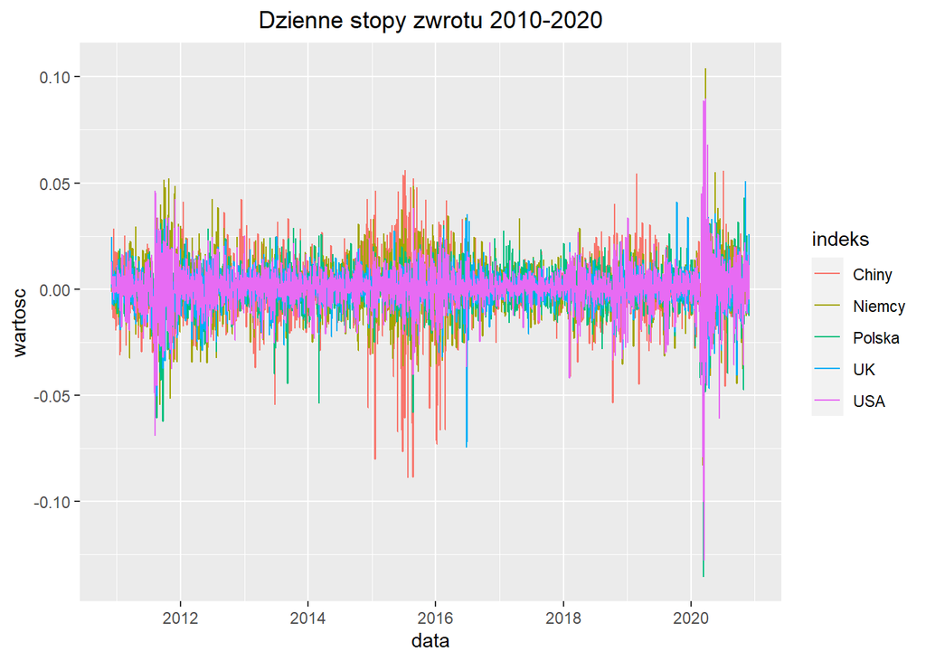

Graficzne przedstawianie dziennych stóp zwrotu z podziałem na poszczególne indeksy:

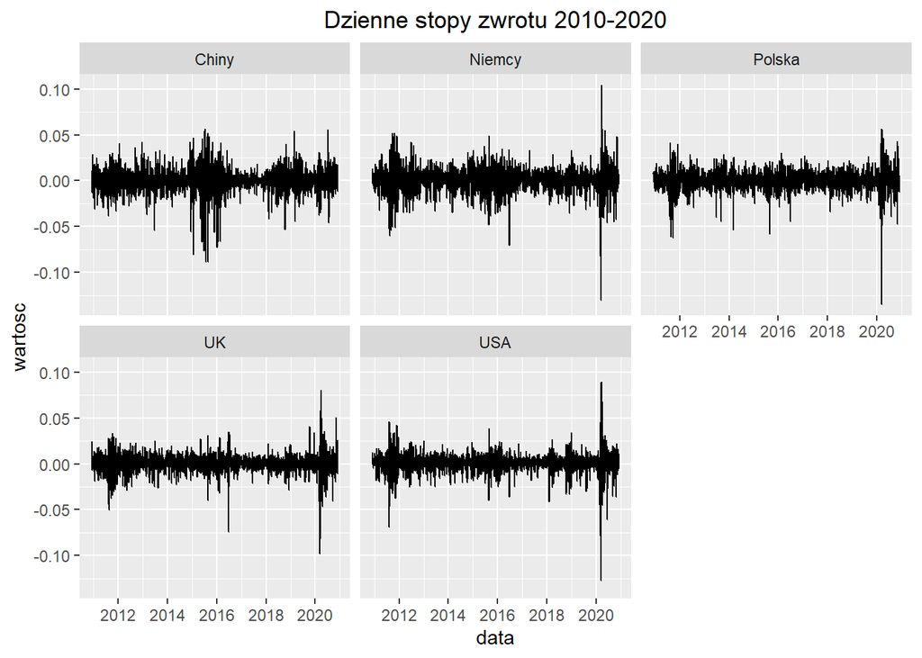

Następnym krokiem było sprawdzenie czy badane szeregi czasowe są stacjonarne:

```r
sapply(stopy_df[2:6], adf.test)
```

```
##             Polska                         Niemcy
## statistic   -12.83423                      -13.35475
## parameter   13                             13
## alternative "stationary"                   "stationary"
## p.value     0.01                           0.01
## method      "Augmented Dickey-Fuller Test" "Augmented Dickey-Fuller Test"
## data.name   "X[[i]]"                       "X[[i]]"
##             UK                             Chiny
## statistic   -12.72718                      -12.93945
## parameter   13                             13
## alternative "stationary"                   "stationary"
## p.value     0.01                           0.01
## method      "Augmented Dickey-Fuller Test" "Augmented Dickey-Fuller Test"
## data.name   "X[[i]]"                       "X[[i]]"
##             USA
## statistic   -13.81936
## parameter   13
## alternative "stationary"
## p.value     0.01
## method      "Augmented Dickey-Fuller Test"
## data.name   "X[[i]]"
```

Po zastosowaniu funkcji logarytmującej wszystkie p-value są niższe niż 5% stąd możemy wnioskować o stacjonarności badanych szeregów co pozwala nam przejść do kolejnych kroków.

## Model VAR

Pierwszym zadaniem podczas realizacji zagadnienia jakim jest estymowanie modelu VAR jest dobór opóźnień. W tym projekcie posłużono się funkcją VARselect i dzięki niej otrzymano 4 kryteria informacyjne pokazane poniżej.

```r
kable(VARselect(stopy_df[-1]), format = "markdown")
```

|  | x |
| --- | --- |
| AIC(n) | 8 |
| HQ(n) | 2 |
| SC(n) | 1 |
| FPE(n) | 8 |

|  | 1 | 2 | 3 | 4 | 5 | 6 | 7 | 8 | 9 | 10 |
| --- | --- | --- | --- | --- | --- | --- | --- | --- | --- | --- |
| AIC(n) | -47.19080 | -47.22006 | -47.22438 | -47.24623 | -47.26472 | -47.27131 | -47.27040 | -47.27228 | -47.26552 | -47.26361 |
| HQ(n) | -47.16622 | -47.17499 | -47.15884 | -47.16021 | -47.15821 | -47.14431 | -47.12293 | -47.10432 | -47.07708 | -47.05469 |
| SC(n) | -47.12297 | -47.09571 | -47.04351 | -47.00884 | -46.97080 | -46.92087 | -46.86344 | -46.80880 | -46.74551 | -46.68709 |
| FPE(n) | 0.00000 | 0.00000 | 0.00000 | 0.00000 | 0.00000 | 0.00000 | 0.00000 | 0.00000 | 0.00000 | 0.00000 |

Otrzymaliśmy następujące opóźnienia: dwa razy 8, 1 oraz 2. W pierwszej kolejności odrzucamy opóźnienia równe 8. W dalszej części naszych rozważań będziemy brać pod uwagę jedynie opóźnienie równe 2 oraz 1. Aby wybrać sporządzone zostaną korelogramy.

- **Korelogramy** dla p=1

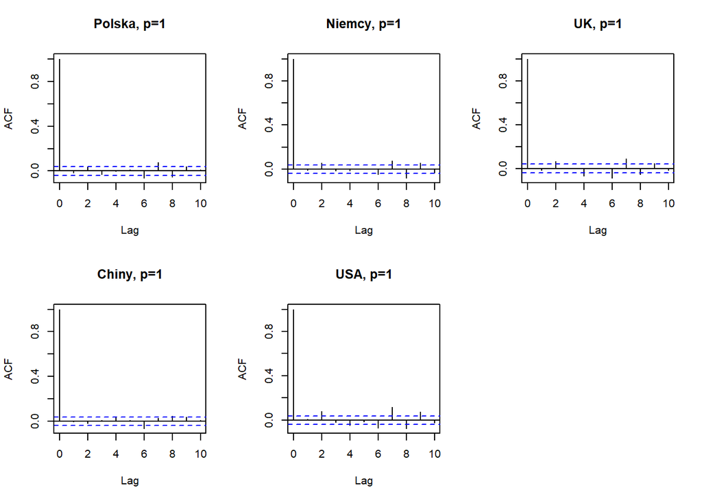

```r
var_model1 <- VAR(stopy_df[2:6], p = 1)
par(mfrow=c(2,3))
acf(var_model1$varresult$Polska$residuals, lag.max = 10, main="Polska, p=1")
acf(var_model1$varresult$Niemcy$residuals, lag.max = 10, main="Niemcy, p=1")
acf(var_model1$varresult$UK$residuals, lag.max = 10, main="UK, p=1")
acf(var_model1$varresult$Chiny$residuals, lag.max = 10, main="Chiny, p=1")
acf(var_model1$varresult$USA$residuals, lag.max = 10, main="USA, p=1")
```

- **Korelogramy** dla p=2

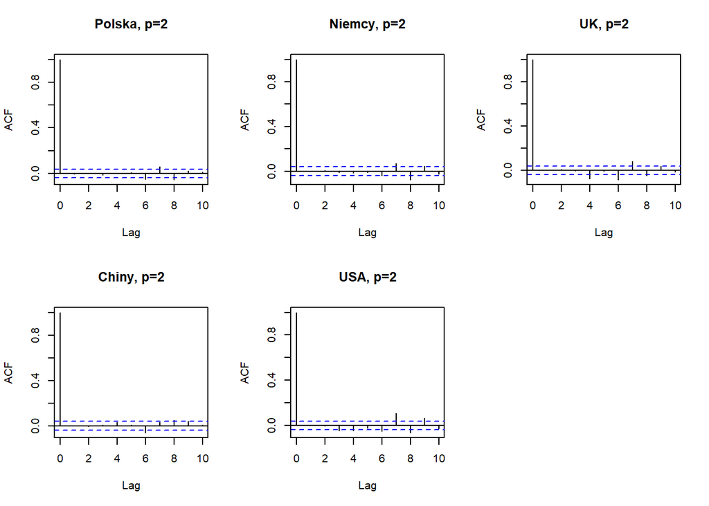

```r
var_model2 <- VAR(stopy_df[2:6], p = 2)
par(mfrow=c(2,3))
acf(var_model2$varresult$Polska$residuals, lag.max = 10, main="Polska, p=2")
acf(var_model2$varresult$Niemcy$residuals, lag.max = 10, main="Niemcy, p=2")
acf(var_model2$varresult$UK$residuals, lag.max = 10, main="UK, p=2")
acf(var_model2$varresult$Chiny$residuals, lag.max = 10, main="Chiny, p=2")
acf(var_model2$varresult$USA$residuals, lag.max = 10, main="USA, p=2")
```

Korelogramy nie dają nam jasnej odpowiedzi na pytanie które opóźnienie jest lepsze. Wszystkie wykresy są bardzo podobne. Z uwagi na ten fakt, w oparciu o uzyskaną wiedzę, w dalszych badaniach posłużymy się opóźnieniem równym 2.

- **Autokorelacja**

Aby zbadać czy nie występuje autokorelacja reszt oraz czy dane są niezależne przeprowadzono testy Ljunga-Boxa.

```
##
##  Box-Ljung test
##
## data:  var_2reszty1
## X-squared = 0.061703, df = 2, p-value = 0.9696
```

```
##
##  Box-Ljung test
##
## data:  var_2reszty2
## X-squared = 0.14874, df = 2, p-value = 0.9283
```

```
##
##  Box-Ljung test
##
## data:  var_2reszty3
## X-squared = 0.22347, df = 2, p-value = 0.8943
```

```
##
##  Box-Ljung test
##
## data:  var_2reszty4
## X-squared = 0.066362, df = 2, p-value = 0.9674
```

```
##
##  Box-Ljung test
##
## data:  var_2reszty5
## X-squared = 0.035745, df = 2, p-value = 0.9823
```

W przypadku każdej zmiennej brak było podstaw do odrzucenia hipotezy zerowej co daje podstawy do wnioskowania iż dane są niezależne oraz wśród reszt nie występuje autokorelacja.

- **Finalny Model VAR**

```r
var_model <- VAR(stopy_df[2:6], p = 2)
summary(var_model)
```

```
##
## VAR Estimation Results:
## =========================
## Endogenous variables: Polska, Niemcy, UK, Chiny, USA
## Deterministic variables: const
## Sample size: 2600
## Log Likelihood: 43005.122
## Roots of the characteristic polynomial:
## 0.3429 0.3418 0.3418 0.302 0.2775 0.2775 0.1794 0.1794 0.1203 0.05906
## Call:
## VAR(y = stopy_df[2:6], p = 2)
##
##
## Estimation results for equation Polska:
## =======================================
## Polska = Polska.l1 + Niemcy.l1 + UK.l1 + Chiny.l1 + USA.l1 + Polska.l2 + Niemcy.l2 + UK.l2 + Chiny.l2 + USA.l2 + const
##
##             Estimate Std. Error t value Pr(>|t|)
## Polska.l1  0.0371912  0.0262042   1.419  0.15594
## Niemcy.l1 -0.0302198  0.0300285  -1.006  0.31433
## UK.l1     -0.1154027  0.0356561  -3.237  0.00123 **
## Chiny.l1  -0.0272803  0.0165014  -1.653  0.09841 .
## USA.l1     0.2358355  0.0267642   8.812  < 2e-16 ***
## Polska.l2 -0.0555864  0.0261340  -2.127  0.03352 *
## Niemcy.l2  0.0329270  0.0298982   1.101  0.27087
## UK.l2      0.0132084  0.0348095   0.379  0.70439
## Chiny.l2  -0.0217870  0.0163759  -1.330  0.18349
## USA.l2     0.1460039  0.0268229   5.443 5.72e-08 ***
## const     -0.0000882  0.0002041  -0.432  0.66567
## ---
## Signif. codes:  0 '***' 0.001 '**' 0.01 '*' 0.05 '.' 0.1 ' ' 1
##
##
## Residual standard error: 0.01038 on 2589 degrees of freedom
## Multiple R-Squared: 0.04569, Adjusted R-squared: 0.042
## F-statistic: 12.39 on 10 and 2589 DF,  p-value: < 2.2e-16
##
##
## Estimation results for equation Niemcy:
## =======================================
```

[output cut: 99 more lines]

```
## Covariance matrix of residuals:
##           Polska    Niemcy        UK     Chiny       USA
## Polska 1.078e-04 8.469e-05 5.909e-05 2.519e-05 5.819e-05
## Niemcy 8.469e-05 1.596e-04 9.911e-05 2.631e-05 8.878e-05
## UK     5.909e-05 9.911e-05 9.673e-05 2.379e-05 6.585e-05
## Chiny  2.519e-05 2.631e-05 2.379e-05 1.606e-04 2.297e-05
## USA    5.819e-05 8.878e-05 6.585e-05 2.297e-05 1.111e-04
##
## Correlation matrix of residuals:
##        Polska Niemcy     UK  Chiny    USA
## Polska 1.0000 0.6457 0.5787 0.1915 0.5317
## Niemcy 0.6457 1.0000 0.7977 0.1643 0.6667
## UK     0.5787 0.7977 1.0000 0.1909 0.6351
## Chiny  0.1915 0.1643 0.1909 1.0000 0.1720
## USA    0.5317 0.6667 0.6351 0.1720 1.0000
```

Analizując otrzymane modele jesteśmy w stanie odpowiedzieć na pytania jaki wpływ mają na siebie wybrane gospodarki z całego świata. Pierwszą rzeczą na jaką powinniśmy zwrócić uwagę jest silne powiązanie giełdy polskiej oraz giełdy Stanów Zjednoczonych zarówno pierwsze jak i drugie opóźnieni wskazują na bardzo silne powiązania. Opóźnienie pierwszego rzędu wskazuje również na powiązania Polski z giełdą Wielkiej Brytanii. Bardzo podobnie sprawa wygląda w przypadku giełdy niemieckiej jak i Brytyjskiej, wynika to z faktu gdyż kraje te są ściśle powiązane z USA. Zapewne zupełnie inaczej wyglądało by to dla krajów takich jak Białoruś czy Ukraina które są mocniej powiązane z Rosją niż z USA. W przypadku drugiej gospodarki na świecie widać powiązania z USA wynika to zapewne z faktu iż gospodarki Stanów oraz Chin są największymi na świecie i nie sposób by nie oddziaływały na siebie. Natomiast jeśli chodzi o same Stany Zjednoczone to zaskakującym może być fakt iż model wskazuje Polską giełdę jaką ta która ma wpływ na giełdę Stanów Zjednoczonych możemy przypuszczać że powodem tego jest fakt, iż Polska jest tak mocno powiązana z USA że samo USA jest powiązane z Polską.

Na przyjętym poziomie istotności 0,05 zależności wyglądają tka jak opisano powyżej, gdbyśmy przyjęli inny poziom istotności sytuacja mogła by wyglądać inaczej lecz nie w przypadku wszystkich krajów.

### Przyczynowość w sensie Grangera

- **Test Grangera**

$H_0:$ wszystkie parametry dla badanych rynków są sobie równe i wynoszą 0  
$H_1:$ przynajmniej jeden parametr z badanych jest różny od 0.

W pierwszej kolejności zbadamy wpływ pozostałych giełd na giełdę Polską.

```r
causality(var_model, cause = c("Niemcy", "UK", "Chiny", "USA"))$Granger
```

```
##
##  Granger causality H0: Niemcy UK Chiny USA do not Granger-cause Polska
##
## data:  VAR object var_model
## F-Test = 13.291, df1 = 8, df2 = 12945, p-value < 2.2e-16
```

Dla poziomu istotności 0,05 p-value przyjmuję taką postać, iż mamy podstawy do odrzucenia H0 możemy zatem wnioskować że wymienione giełdy wpływają na giełdę Polska. Inaczej mówiąc są jej przyczynami w sensie Grangera.

Następnym krokiem będzie ocenieni przyczynowości w sensie Grangera dla pozostałych giełd. Hipotezy będą wyglądać następująco:

$H_0:$ badany czynnik wynosi 0, tzn. nie ma wpływu na pozostałe  
$H_1:$ wartość badanego czynnika jest różna od 0; ma on wpływ na pozostałe czynniki

```r
causality(var_model, cause = "Polska")$Granger
```

```
##
##  Granger causality H0: Polska do not Granger-cause Niemcy UK Chiny USA
##
## data:  VAR object var_model
## F-Test = 1.9232, df1 = 8, df2 = 12945, p-value = 0.05216
```

```r
causality(var_model, cause = "Niemcy")$Granger
```

```
##
##  Granger causality H0: Niemcy do not Granger-cause Polska UK Chiny USA
##
## data:  VAR object var_model
## F-Test = 2.5599, df1 = 8, df2 = 12945, p-value = 0.008703
```

```r
causality(var_model, cause = "UK")$Granger
```

```
##
##  Granger causality H0: UK do not Granger-cause Polska Niemcy Chiny USA
##
## data:  VAR object var_model
## F-Test = 5.247, df1 = 8, df2 = 12945, p-value = 1.403e-06
```

```r
causality(var_model, cause = "Chiny")$Granger
```

```
##
##  Granger causality H0: Chiny do not Granger-cause Polska Niemcy UK USA
##
## data:  VAR object var_model
## F-Test = 1.9867, df1 = 8, df2 = 12945, p-value = 0.04402
```

W powyższym przypadku p-value wynosi 0.04402 jest to mniej niż 5% stąd możemy wniskowac że w tym przypadku zachodzi przyczynowość w sesnie Grangera względem pozostałych giełd.

```r
causality(var_model, cause = "USA")$Granger
```

```
##
##  Granger causality H0: USA do not Granger-cause Polska Niemcy UK Chiny
##
## data:  VAR object var_model
## F-Test = 17.789, df1 = 8, df2 = 12945, p-value < 2.2e-16
```

## Reakcja na impuls

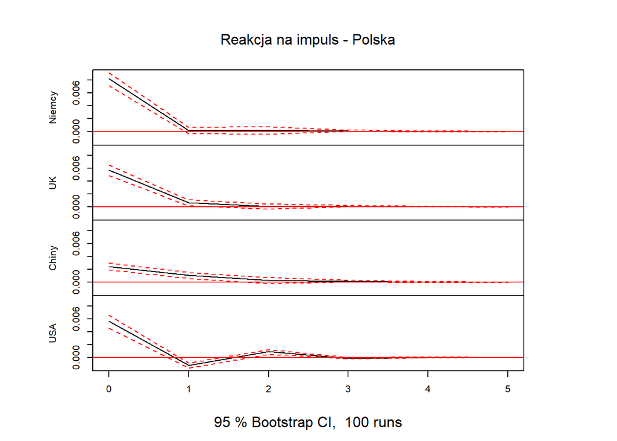

```r
impuls_1<-irf(var_model, impulse="Polska", response=c("Niemcy", "UK", "Chiny", "USA"), n.ahead=5, ortho=TRUE, runs=100)
plot(impuls_1, main="Reakcja na impuls - Polska")
```

Pierwszy z wykresów nie pokazuje zbyt wiele widać. Co prawda niewielka reakcje giełdy USA po wytworzeniu impulsu z giełdy Polskiej. Reakcja ta jednak zanika już po 2 dniach, a wynika zapewne z powiązań omawianych we wcześniejszej części projektu.

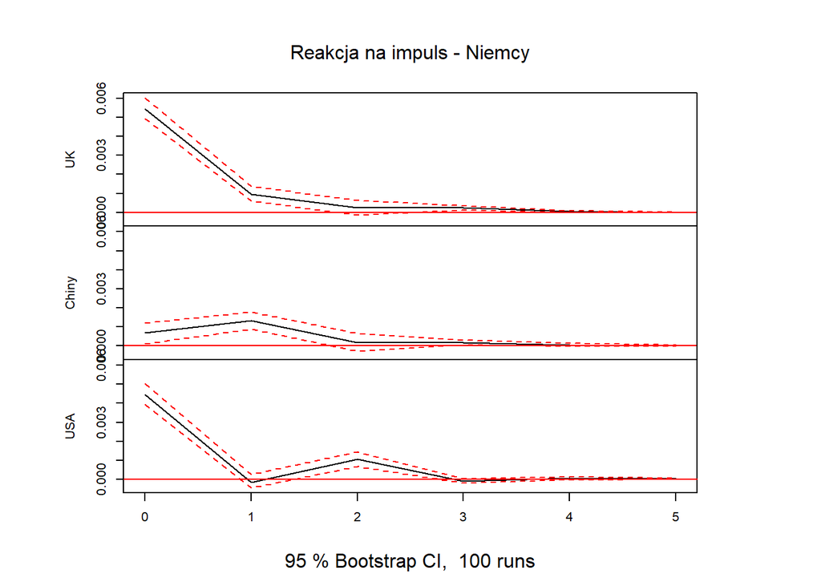

```r
impuls_2<-irf(var_model, impulse="Niemcy", response=c("UK", "Chiny", "USA"), n.ahead=5, ortho=TRUE, runs=100)
plot(impuls_2, main="Reakcja na impuls - Niemcy")
```

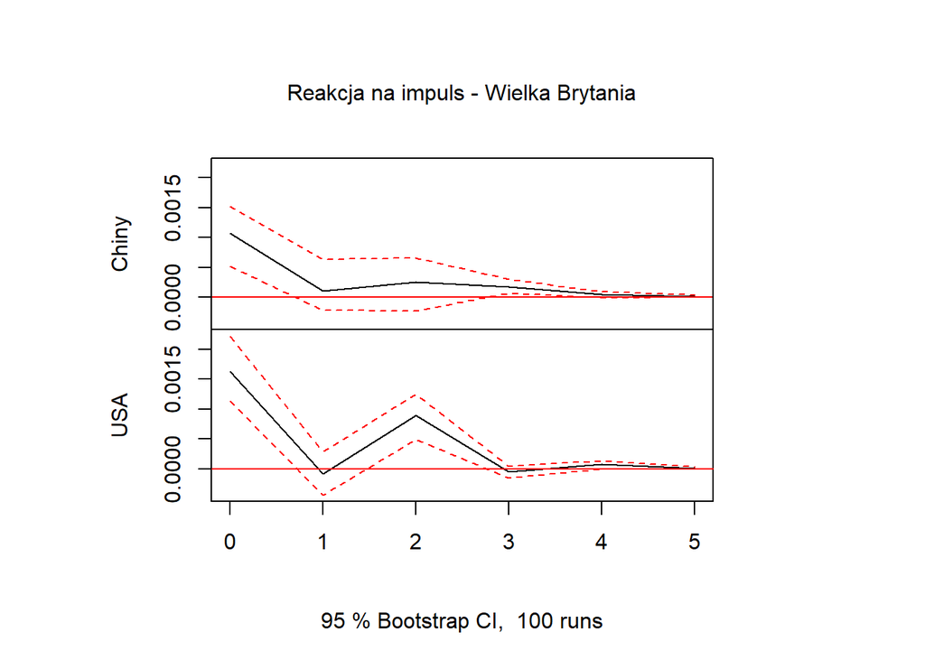

```r
impuls_3<-irf(var_model, impulse="UK", response=c("Chiny", "USA"), n.ahead=5, ortho=TRUE, runs=100)
plot(impuls_3, main="Reakcja na impuls - Wielka Brytania")
```

Trzeci z przedstawionych wykresów pokazuje reakcje na impuls z giełdy w Wielkiej Brytanii. O ile reakcja giełdy Chińskiej nie jest zbyt duża to w przypadku giełdy Stanów Zjednoczonych możemy zaobserwować dość dynamiczny wzrost.

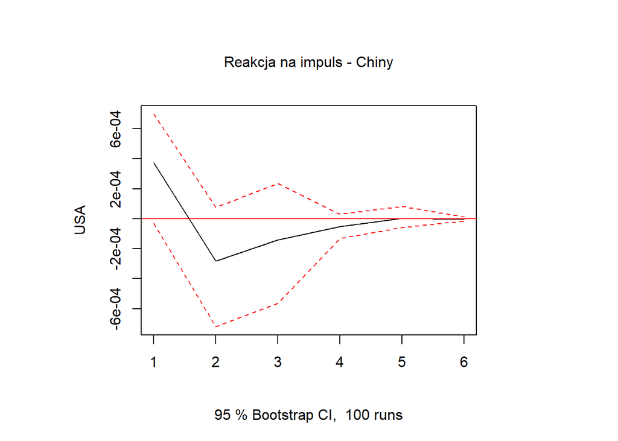

```r
impuls_4<-irf(var_model, impulse="Chiny", response=c("USA"), n.ahead=5, ortho=TRUE, runs=100)
plot(impuls_4, main="Reakcja na impuls - Chiny")
```